# Projet: Rendez-vous d'Hopitaux Manqués

*Auteur: Franck Alain Binde Koube*

### Base de données utilisée: Database_No_show_appointments

## Table des matières

- I - Introduction
- II - Data Wrangling
- III - Analyse exploratoire des données
- IV - Conclusions

## I - Introduction

Dans ce projet, nous analyserons les données concernant des rendez-vous de patients dans des centres hospitaliers au Brésil.

Chaque observation (ou ligne) nous donne les détails sur un rendez-vous en particulier. Pour chaque rendez-vous, des atributs spécifiques sont répertoriés.

Les différentes colonnes présentes dans la table de données sont:

- **PatientId**: Identifiant unique du patient
- **AppointmentID**: Identifiant unique du rendez-vous
- **Gender**: Sexe du patient
- **ScheduledDay**: Jour et heure du rendez-vous
- **AppointmentDay**: Jour du rendez-vous
- **Age**: Age du patient
- **Neighbourhood**: Localisation du centre hospitalier
- **Scholarship**: Indique si le patient est inscrit au programme d'aide sociale brésilienne Bolsa Familia.
- **Hipertension**: Indique si le patient est atteint d'hypertension
- **Diabetes**: Indique si le patient est atteint de diabete
- **Alcoholism**: Indique si le patient est atteint d'alcoolisme
- **Handcap**: Indique si le patient souffre d'un handicap
- **SMS_received**: Indique si le patient a reçu un ou plusieurs messages
- **No-show**: Indique si le patient s'est présenté au rendez-vous

Vous pouvez consulter la source de ces données [ici](https://www.kaggle.com/joniarroba/noshowappointments).

[figure not shown]

Une telle base de données soulève quelques questions.

1. Comment est la distribution de l'âge des patients?
2. Les patients d'un certain âge manquent t-ils plus leur rendez-vous ?
3. Quelles sont les localisations où les proportions de rendez-vous manqués sont les plus élevées?
4. Y a-t-il des jours de la semaine où les rendez-vous sont le plus manqués ?
5. Qu’en est-il des heures de rendez-vous ?
6. Les patients qui ont reçu des messages viennent t-ils plus à leur rendez-vous?

```python
# Importons les librairies dont nous avons besoin

import pandas as pd
import numpy as np
import matplotlib.pyplot as plt
import seaborn as sns
sns.set_theme()

%matplotlib inline
```

## II - Data Wrangling

### Propriétés Générales

Nous allons télécharger nos données et les nettoyer. Cette première étape consiste à assainir nos données pour pouvoir faciliter notre analyse. Ainsi, nous pourrons :

- Supprimer les doublons (s'il y'en a)
- Traiter les valeur manquantes (s'il y en a)
- Modifier le type de données de certaines colonnes
- Modifier certains noms de colonnes
- Créer de nouvelles colonnes

```python
# importons notre table de données, et explorons la.
df = pd.read_csv('noshowappointments-may-2016.csv')
df.head()
```

|  | PatientId | AppointmentID | Gender | ScheduledDay | AppointmentDay | Age | Neighbourhood | Scholarship | Hipertension | Diabetes | Alcoholism | Handcap | SMS_received | No-show |
| --- | --- | --- | --- | --- | --- | --- | --- | --- | --- | --- | --- | --- | --- | --- |
| 0 | 2.987250e+13 | 5642903 | F | 2016-04-29T18:38:08Z | 2016-04-29T00:00:00Z | 62 | JARDIM DA PENHA | 0 | 1 | 0 | 0 | 0 | 0 | No |
| 1 | 5.589978e+14 | 5642503 | M | 2016-04-29T16:08:27Z | 2016-04-29T00:00:00Z | 56 | JARDIM DA PENHA | 0 | 0 | 0 | 0 | 0 | 0 | No |
| 2 | 4.262962e+12 | 5642549 | F | 2016-04-29T16:19:04Z | 2016-04-29T00:00:00Z | 62 | MATA DA PRAIA | 0 | 0 | 0 | 0 | 0 | 0 | No |
| 3 | 8.679512e+11 | 5642828 | F | 2016-04-29T17:29:31Z | 2016-04-29T00:00:00Z | 8 | PONTAL DE CAMBURI | 0 | 0 | 0 | 0 | 0 | 0 | No |
| 4 | 8.841186e+12 | 5642494 | F | 2016-04-29T16:07:23Z | 2016-04-29T00:00:00Z | 56 | JARDIM DA PENHA | 0 | 1 | 1 | 0 | 0 | 0 | No |

**Déterminons la dimension de notre table de données** 🢃

```python
df.shape
```

```
(110527, 14)
```

Nombre de lignes: **110527**  
Nombre de colonnes: **14**

Vérifions s'il y a des doublons.

```python
print("Nombre de doublons:")
print(df.duplicated().sum())
```

```
Nombre de doublons:
0
```

Notre tableau de données ne contient pas de doublons. Continuons notre inspection

**Inspectons les colonnes** 🢃

```python
df.info()
```

```
<class 'pandas.core.frame.DataFrame'>
RangeIndex: 110527 entries, 0 to 110526
Data columns (total 14 columns):
 #   Column          Non-Null Count   Dtype
---  ------          --------------   -----
 0   PatientId       110527 non-null  float64
 1   AppointmentID   110527 non-null  int64
 2   Gender          110527 non-null  object
 3   ScheduledDay    110527 non-null  object
 4   AppointmentDay  110527 non-null  object
 5   Age             110527 non-null  int64
 6   Neighbourhood   110527 non-null  object
 7   Scholarship     110527 non-null  int64
 8   Hipertension    110527 non-null  int64
 9   Diabetes        110527 non-null  int64
 10  Alcoholism      110527 non-null  int64
 11  Handcap         110527 non-null  int64
 12  SMS_received    110527 non-null  int64
 13  No-show         110527 non-null  object
dtypes: float64(1), int64(8), object(5)
memory usage: 11.8+ MB
```

### Quelques observations

▶ Il n'y **aucune valeur manquante** dans nos données.

▶ Les colonnes *PatientId* et *AppointmentID* sont de types numérique. Vu qu'aucun calcul statistique ne se fera sur ces valeurs, nous les convertirons en type string (objet sur pandas)

▶ Les colonnes *ScheduledDay* et *AppointmentDay* sont de type objet. Nous les convertirons en type date pour pouvoir mieux les manipuler.

### Modification du type de données des colonnes

```python
# Création de la fontion qui permettra de modifier le type de données des colonnes

def change_col_type(col):
    if df[col].dtype in ['int64', 'float64']:
        df[col] = df[col].astype(str)
    elif df[col].dtype == 'object':
        df[col] = pd.to_datetime(df[col])
```

```python
# Modification du type de données des colonnes

cols = ['PatientId', 'AppointmentID', 'ScheduledDay', 'AppointmentDay']
for col in cols:
    change_col_type(col)
```

```python
# Vérifions que nos modifications ont bien fonctionné
df.info()
```

```
<class 'pandas.core.frame.DataFrame'>
RangeIndex: 110527 entries, 0 to 110526
Data columns (total 14 columns):
 #   Column          Non-Null Count   Dtype
---  ------          --------------   -----
 0   PatientId       110527 non-null  object
 1   AppointmentID   110527 non-null  object
 2   Gender          110527 non-null  object
 3   ScheduledDay    110527 non-null  datetime64[ns, UTC]
 4   AppointmentDay  110527 non-null  datetime64[ns, UTC]
 5   Age             110527 non-null  int64
 6   Neighbourhood   110527 non-null  object
 7   Scholarship     110527 non-null  int64
 8   Hipertension    110527 non-null  int64
 9   Diabetes        110527 non-null  int64
 10  Alcoholism      110527 non-null  int64
 11  Handcap         110527 non-null  int64
 12  SMS_received    110527 non-null  int64
 13  No-show         110527 non-null  object
dtypes: datetime64[ns, UTC](2), int64(7), object(5)
memory usage: 11.8+ MB
```

La modification a fonctionné. *PatientId* et *AppointmentID* sont maintenant de type objet. *ScheduledDay* et *AppointmentDay* sont de type date. Nous avons donc les types de données souhaités.

```python
# Inspectons la colonne No-show
df['No-show'].unique()
```

```
array(['No', 'Yes'], dtype=object)
```

> La colonne *No-show* contient deux valeurs: "Yes" et "No". La valeur "Yes" signifie qu'un patient a manqué son rendez-vous.  
> **No-show = "Yes"**: Rendez-vous manqué  
> **No-show = "No"**: Rendez-vous honoré

> Cette colonne est binaire (Yes - No). Pour gagner en temps et bénéficier de la puissance des fonctions numériques de numpy et pandas, nous convertirons cette colonne en colonne numérique. Pour ce faire, nous remplacerons d'abord les valeurs "Yes" par "1", et "No" par 0.

```python
# Remplacement des valeurs

df['No-show'] = np.where(df['No-show'] == "Yes", 1, 0)
df['No-show'].value_counts()
```

```
0    88208
1    22319
Name: No-show, dtype: int64
```

```python
# Modification du type de données
df['No-show'] = df['No-show'].astype(int)
df['No-show'].dtypes
```

```
dtype('int32')
```

> **La colonne *No-show* ne contient maintenant que soit des 1, soit des 0. Elle est de type entier.**

> Remarque: Certaines fonctions de pandas (telles que **query**) n'autorisent pas des noms de colonnes qui contiennent des tirets(-). Nous allons donc modifier le nom de la colonne **No-show** par **No_show**

### Modification du nom de colonne

```python
df.rename(columns={'No-show': 'No_show'}, inplace=True)
# Vérifions que tout s'est bien passé
df.columns
```

```
Index(['PatientId', 'AppointmentID', 'Gender', 'ScheduledDay',
       'AppointmentDay', 'Age', 'Neighbourhood', 'Scholarship', 'Hipertension',
       'Diabetes', 'Alcoholism', 'Handcap', 'SMS_received', 'No_show'],
      dtype='object')
```

### Statistiques de base

Maintenant que nos colonnes ont des types appropriés, nous pouvons inspecter quelques statistiques de base sur les valeurs numériques.

```python
print("Tableau statistique:")
df.describe()
```

```
Tableau statistique:
```

|  | Age | Scholarship | Hipertension | Diabetes | Alcoholism | Handcap | SMS_received | No_show |
| --- | --- | --- | --- | --- | --- | --- | --- | --- |
| count | 110527.000000 | 110527.000000 | 110527.000000 | 110527.000000 | 110527.000000 | 110527.000000 | 110527.000000 | 110527.000000 |
| mean | 37.088874 | 0.098266 | 0.197246 | 0.071865 | 0.030400 | 0.022248 | 0.321026 | 0.201933 |
| std | 23.110205 | 0.297675 | 0.397921 | 0.258265 | 0.171686 | 0.161543 | 0.466873 | 0.401444 |
| min | -1.000000 | 0.000000 | 0.000000 | 0.000000 | 0.000000 | 0.000000 | 0.000000 | 0.000000 |
| 25% | 18.000000 | 0.000000 | 0.000000 | 0.000000 | 0.000000 | 0.000000 | 0.000000 | 0.000000 |
| 50% | 37.000000 | 0.000000 | 0.000000 | 0.000000 | 0.000000 | 0.000000 | 0.000000 | 0.000000 |
| 75% | 55.000000 | 0.000000 | 0.000000 | 0.000000 | 0.000000 | 0.000000 | 1.000000 | 0.000000 |
| max | 115.000000 | 1.000000 | 1.000000 | 1.000000 | 1.000000 | 4.000000 | 1.000000 | 1.000000 |

La moyenne de la colonne **No_show** est de **0.20**. Ce qui signifie qu'environ **20%** des rendez-vous de notre base de données **n'ont pas été honorés.**

### Creation de nouvelles colonnes

> En introduction de ce projet, nous avons des questions relatives aux jours de la semaine et aux heures. En effet, nous aimerions savoir s'il y a des jours et des heures en particulier où les patients ont plus souvent manqué un rendez-vous. Nous allons donc créer deux nouvelles colonnes, à savoir:
> - la colonne **Appointment_dow**: dans laquelle nous allons extraire le jour de la semaine à partir de la colonne **AppointmentDay**
> - la colonne **Appointment_hour**: dans laquelle nous allons extraire l'heure de début du rendez-vous à partir de la colonne **ScheduledDay**

```python
# Création des colonnes 'Appointment_dow' et 'Appointment_hour'
df['Appointment_dow'] = df['AppointmentDay'].dt.dayofweek
df['Appointment_hour'] = df['ScheduledDay'].dt.hour
# Vérification du résultat
df.head()
```

|  | PatientId | AppointmentID | Gender | ScheduledDay | AppointmentDay | Age | Neighbourhood | Scholarship | Hipertension | Diabetes | Alcoholism | Handcap | SMS_received | No_show | Appointment_dow | Appointment_hour |
| --- | --- | --- | --- | --- | --- | --- | --- | --- | --- | --- | --- | --- | --- | --- | --- | --- |
| 0 | 29872499824296.0 | 5642903 | F | 2016-04-29 18:38:08+00:00 | 2016-04-29 00:00:00+00:00 | 62 | JARDIM DA PENHA | 0 | 1 | 0 | 0 | 0 | 0 | 0 | 4 | 18 |
| 1 | 558997776694438.0 | 5642503 | M | 2016-04-29 16:08:27+00:00 | 2016-04-29 00:00:00+00:00 | 56 | JARDIM DA PENHA | 0 | 0 | 0 | 0 | 0 | 0 | 0 | 4 | 16 |
| 2 | 4262962299951.0 | 5642549 | F | 2016-04-29 16:19:04+00:00 | 2016-04-29 00:00:00+00:00 | 62 | MATA DA PRAIA | 0 | 0 | 0 | 0 | 0 | 0 | 0 | 4 | 16 |
| 3 | 867951213174.0 | 5642828 | F | 2016-04-29 17:29:31+00:00 | 2016-04-29 00:00:00+00:00 | 8 | PONTAL DE CAMBURI | 0 | 0 | 0 | 0 | 0 | 0 | 0 | 4 | 17 |
| 4 | 8841186448183.0 | 5642494 | F | 2016-04-29 16:07:23+00:00 | 2016-04-29 00:00:00+00:00 | 56 | JARDIM DA PENHA | 0 | 1 | 1 | 0 | 0 | 0 | 0 | 4 | 16 |

Signification des valeurs de **Appointment_dow:**

- **0:** Lundi
- **1:** Mardi
- **2:** Mercredi
- **3:** Jeudi
- **4:** Vendredi
- **5:** Samedi
- **6:** Dimanche

Nous allons remplacer les valeurs par defaut de la colonne *Appointment_dow* par les noms des jours de la semaine.

```python
# On crée une série conditionnelle pour faire correspondre les numéros des jours de la semaine aux noms
dow = np.where(df.Appointment_dow == 0, "Monday",
                         np.where(df.Appointment_dow == 1, "Tuesday",
                         np.where(df.Appointment_dow == 2, "Wednesday",
                         np.where(df.Appointment_dow == 3, "Thursday",
                         np.where(df.Appointment_dow == 4, "Friday",
                         np.where(df.Appointment_dow == 5, "Saturday", "Sunday"))))))

# On remplace la colonne actuelle par la série nouvellement créee
df['Appointment_dow'] = dow
df.head()
```

|  | PatientId | AppointmentID | Gender | ScheduledDay | AppointmentDay | Age | Neighbourhood | Scholarship | Hipertension | Diabetes | Alcoholism | Handcap | SMS_received | No_show | Appointment_dow | Appointment_hour |
| --- | --- | --- | --- | --- | --- | --- | --- | --- | --- | --- | --- | --- | --- | --- | --- | --- |
| 0 | 29872499824296.0 | 5642903 | F | 2016-04-29 18:38:08+00:00 | 2016-04-29 00:00:00+00:00 | 62 | JARDIM DA PENHA | 0 | 1 | 0 | 0 | 0 | 0 | 0 | Friday | 18 |
| 1 | 558997776694438.0 | 5642503 | M | 2016-04-29 16:08:27+00:00 | 2016-04-29 00:00:00+00:00 | 56 | JARDIM DA PENHA | 0 | 0 | 0 | 0 | 0 | 0 | 0 | Friday | 16 |
| 2 | 4262962299951.0 | 5642549 | F | 2016-04-29 16:19:04+00:00 | 2016-04-29 00:00:00+00:00 | 62 | MATA DA PRAIA | 0 | 0 | 0 | 0 | 0 | 0 | 0 | Friday | 16 |
| 3 | 867951213174.0 | 5642828 | F | 2016-04-29 17:29:31+00:00 | 2016-04-29 00:00:00+00:00 | 8 | PONTAL DE CAMBURI | 0 | 0 | 0 | 0 | 0 | 0 | 0 | Friday | 17 |
| 4 | 8841186448183.0 | 5642494 | F | 2016-04-29 16:07:23+00:00 | 2016-04-29 00:00:00+00:00 | 56 | JARDIM DA PENHA | 0 | 1 | 1 | 0 | 0 | 0 | 0 | Friday | 16 |

Il sera aussi question de savoir si les patients d'un certain âge ont plus manqué leur rendez-vous. Nous allons donc créer la colonne **age_group** qui va diviser les patients en differents groupes en fonction de leur âge.

```python
# création des valeurs limitrophes pour les groupes en fonction de l'âge
ages_bound = [0, 10, 20, 30, 40, 50, 60, 70, 80, 90, 115]
# création des libellés de chaque groupe d'âge
ages_group = ['0-10', '10-20', '20-30', '30-40', '40-50', '50-60', '60-70', '70-80', '80-90', '90-115']
# création de la nouvelle colonne age_group
df['age_group'] = pd.cut(df.Age, ages_bound, ages_group)
# vérification des resultats
df.head()
```

|  | PatientId | AppointmentID | Gender | ScheduledDay | AppointmentDay | Age | Neighbourhood | Scholarship | Hipertension | Diabetes | Alcoholism | Handcap | SMS_received | No_show | Appointment_dow | Appointment_hour | age_group |
| --- | --- | --- | --- | --- | --- | --- | --- | --- | --- | --- | --- | --- | --- | --- | --- | --- | --- |
| 0 | 29872499824296.0 | 5642903 | F | 2016-04-29 18:38:08+00:00 | 2016-04-29 00:00:00+00:00 | 62 | JARDIM DA PENHA | 0 | 1 | 0 | 0 | 0 | 0 | 0 | Friday | 18 | (60, 70] |
| 1 | 558997776694438.0 | 5642503 | M | 2016-04-29 16:08:27+00:00 | 2016-04-29 00:00:00+00:00 | 56 | JARDIM DA PENHA | 0 | 0 | 0 | 0 | 0 | 0 | 0 | Friday | 16 | (50, 60] |
| 2 | 4262962299951.0 | 5642549 | F | 2016-04-29 16:19:04+00:00 | 2016-04-29 00:00:00+00:00 | 62 | MATA DA PRAIA | 0 | 0 | 0 | 0 | 0 | 0 | 0 | Friday | 16 | (60, 70] |
| 3 | 867951213174.0 | 5642828 | F | 2016-04-29 17:29:31+00:00 | 2016-04-29 00:00:00+00:00 | 8 | PONTAL DE CAMBURI | 0 | 0 | 0 | 0 | 0 | 0 | 0 | Friday | 17 | (0, 10] |
| 4 | 8841186448183.0 | 5642494 | F | 2016-04-29 16:07:23+00:00 | 2016-04-29 00:00:00+00:00 | 56 | JARDIM DA PENHA | 0 | 1 | 1 | 0 | 0 | 0 | 0 | Friday | 16 | (50, 60] |

Nous avons nettoyé nos données et crée de nouvelles colonnes. Nous pouvons à présent passer à une exploration plus appronfondie, dans le but de répondre à nos interrogations.

## III - Analyse exploratoire des données

> Petit rappel sur les questions de base:
1. Comment est la distribution de l'âge des patients de cette base de données ?
2. Les patients d'un certain âge manquent t-ils plus leur rendez-vous ?
3. Quelles sont les localisations où les proportions de rendez-vous manqués sont les plus élevées?
4. Y a-t-il des jours de la semaine où les rendez-vous sont le plus manqués ?
5. Qu’en est-il des heures de rendez-vous ?
6. Les patients qui ont reçu des messages viennent t-ils plus à leur rendez-vous?

### Question 1 : Comment est la distribution de l'âge des patients de cette base de données ?

Nous allons générer un histogramme permettant de visualiser cette distribution.

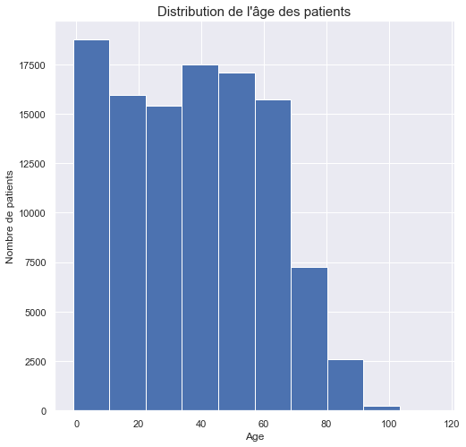

```python
plt.figure(figsize=(8, 8))
plt.hist(df.Age)
plt.xlabel("Age")
plt.ylabel("Nombre de patients")
plt.title("Distribution de l'âge des patients", fontsize=15);
```

### Question 2 : Les patients d'un certain âge manquent t-ils plus leur rendez-vous ?

Nous allons inspecter la **proportion des rendez-vous manqués par groupe d'âge**.

```python
# on trouve le nombre TOTAL de rendez-vous pour chaque groupe
ages_group = df.groupby('age_group').count()
print("Nombre total de rendez-vous")
ages_group['AppointmentID']
```

```
Nombre total de rendez-vous
```

```
age_group
(0, 10]      15210
(10, 20]     13099
(20, 30]     13783
(30, 40]     15052
(40, 50]     14420
(50, 60]     15661
(60, 70]     11189
(70, 80]      5721
(80, 90]      2544
(90, 115]      308
Name: AppointmentID, dtype: int64
```

```python
# on trouve le nombre de rendez-vous manqués pour chaque groupe
ages_group_not_show = df.query('No_show == 1').groupby('age_group').count()
print("Nombre de rendez-vous manqués pour chaque groupe")
ages_group_not_show['AppointmentID']
```

```
Nombre de rendez-vous manqués pour chaque groupe
```

```
age_group
(0, 10]      3149
(10, 20]     3308
(20, 30]     3394
(30, 40]     3232
(40, 50]     2870
(50, 60]     2721
(60, 70]     1648
(70, 80]      889
(80, 90]      407
(90, 115]      62
Name: AppointmentID, dtype: int64
```

```python
# on trouve la proportion de rendez-vous manqués pour chaque groupe
prop_ages_group_not_show = ages_group_not_show.AppointmentID / ages_group.AppointmentID
print("Proportion de rendez-vous manqués pour chaque groupe")
prop_ages_group_not_show.sort_values(ascending=False)
```

```
Proportion de rendez-vous manqués pour chaque groupe
```

```
age_group
(10, 20]     0.252538
(20, 30]     0.246245
(30, 40]     0.214722
(0, 10]      0.207035
(90, 115]    0.201299
(40, 50]     0.199029
(50, 60]     0.173744
(80, 90]     0.159984
(70, 80]     0.155392
(60, 70]     0.147288
Name: AppointmentID, dtype: float64
```

**Visualisons ces proportions sur un graphe**

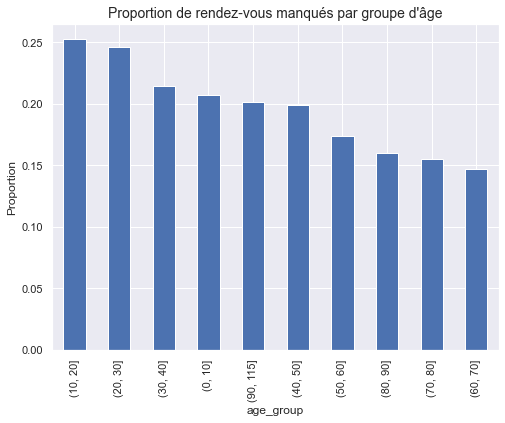

```python
plt.figure(figsize=(8, 6))
prop_ages_group_not_show.sort_values(ascending=False).plot(kind='bar')
plt.title("Proportion de rendez-vous manqués par groupe d'âge", fontsize=14)
plt.ylabel("Proportion");
```

Les groupes de 10-20 ans et 20-30 ans sont ceux avec les plus grandes proportions de rendez-vous manqués avec:

- **10-20 ans**: 25.3% de rendez-vous manqués
- **20-30 ans**: 24.6% de rendez-vous manqués

### Question 3 : Quelles sont les localisations où les proportions de rendez-vous manqués sont les plus élevées?

Inspectons la colonne *Neighbourhood*. Déterminons le nombre de rendez-vous pour chaque localisation.

```python
# Nombre de rendez-vous pour chaque localisation
# Déterminons les 10 localisations avec le moins de rendez-vous
print("Nombre de rendez-vous")
df['Neighbourhood'].value_counts().sort_values().head(10)
```

```
Nombre de rendez-vous
```

```
PARQUE INDUSTRIAL                1
ILHAS OCEÂNICAS DE TRINDADE      2
AEROPORTO                        8
ILHA DO FRADE                   10
ILHA DO BOI                     35
PONTAL DE CAMBURI               69
MORADA DE CAMBURI               96
NAZARETH                       135
SEGURANÇA DO LAR               145
UNIVERSITÁRIO                  152
Name: Neighbourhood, dtype: int64
```

Certaines localisations n'ont que très peu de rendez-vous. Les inclure dans notre analyse ne serait pas judicieux. Nous allons nous concentrer sur les localisations avec plus de 200 rendez-vous.  
Mais d'abord, visualisons les 10 localisations avec le plus de rendez-vous.

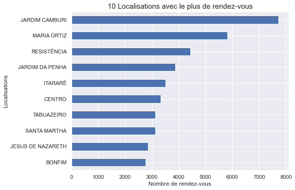

```python
plt.figure(figsize=(8, 6))
df['Neighbourhood'].value_counts().sort_values(ascending=False).head(10).sort_values().plot(kind='barh')
plt.ylabel("Localisations")
plt.xlabel("Nombre de rendez-vous")
plt.title("10 Localisations avec le plus de rendez-vous", fontsize=15);
```

```python
# Déterminons les localisations qui ont plus de 200 rendez-vous
neighbourhood = df.groupby('Neighbourhood').count()
nbhood_mst_freqt = neighbourhood.loc[neighbourhood['AppointmentID'] >= 200, :]
nbhood_mst_freqt
```

| Neighbourhood | PatientId | AppointmentID | Gender | ScheduledDay | AppointmentDay | Age | Scholarship | Hipertension | Diabetes | Alcoholism | Handcap | SMS_received | No_show | Appointment_dow | Appointment_hour | age_group |
| --- | --- | --- | --- | --- | --- | --- | --- | --- | --- | --- | --- | --- | --- | --- | --- | --- |
| ANDORINHAS | 2262 | 2262 | 2262 | 2262 | 2262 | 2262 | 2262 | 2262 | 2262 | 2262 | 2262 | 2262 | 2262 | 2262 | 2262 | 2195 |
| ANTÔNIO HONÓRIO | 271 | 271 | 271 | 271 | 271 | 271 | 271 | 271 | 271 | 271 | 271 | 271 | 271 | 271 | 271 | 257 |
| ARIOVALDO FAVALESSA | 282 | 282 | 282 | 282 | 282 | 282 | 282 | 282 | 282 | 282 | 282 | 282 | 282 | 282 | 282 | 268 |
| BARRO VERMELHO | 423 | 423 | 423 | 423 | 423 | 423 | 423 | 423 | 423 | 423 | 423 | 423 | 423 | 423 | 423 | 418 |
| BELA VISTA | 1907 | 1907 | 1907 | 1907 | 1907 | 1907 | 1907 | 1907 | 1907 | 1907 | 1907 | 1907 | 1907 | 1907 | 1907 | 1834 |
| ... | ... | ... | ... | ... | ... | ... | ... | ... | ... | ... | ... | ... | ... | ... | ... | ... |
| SÃO CRISTÓVÃO | 1836 | 1836 | 1836 | 1836 | 1836 | 1836 | 1836 | 1836 | 1836 | 1836 | 1836 | 1836 | 1836 | 1836 | 1836 | 1785 |
| SÃO JOSÉ | 1977 | 1977 | 1977 | 1977 | 1977 | 1977 | 1977 | 1977 | 1977 | 1977 | 1977 | 1977 | 1977 | 1977 | 1977 | 1868 |
| SÃO PEDRO | 2448 | 2448 | 2448 | 2448 | 2448 | 2448 | 2448 | 2448 | 2448 | 2448 | 2448 | 2448 | 2448 | 2448 | 2448 | 2346 |
| TABUAZEIRO | 3132 | 3132 | 3132 | 3132 | 3132 | 3132 | 3132 | 3132 | 3132 | 3132 | 3132 | 3132 | 3132 | 3132 | 3132 | 3019 |
| VILA RUBIM | 851 | 851 | 851 | 851 | 851 | 851 | 851 | 851 | 851 | 851 | 851 | 851 | 851 | 851 | 851 | 829 |

69 rows × 16 columns

```python
# Stockons le nom de ces localisations
nbhood_sup_200_names = nbhood_mst_freqt.index
nbhood_sup_200_names
```

```
Index(['ANDORINHAS', 'ANTÔNIO HONÓRIO', 'ARIOVALDO FAVALESSA',
       'BARRO VERMELHO', 'BELA VISTA', 'BENTO FERREIRA', 'BOA VISTA', 'BONFIM',
       'CARATOÍRA', 'CENTRO', 'COMDUSA', 'CONQUISTA', 'CONSOLAÇÃO',
       'CRUZAMENTO', 'DA PENHA', 'DE LOURDES', 'DO CABRAL', 'DO MOSCOSO',
       'DO QUADRO', 'ENSEADA DO SUÁ', 'ESTRELINHA', 'FONTE GRANDE',
       'FORTE SÃO JOÃO', 'FRADINHOS', 'GOIABEIRAS', 'GRANDE VITÓRIA',
       'GURIGICA', 'ILHA DAS CAIEIRAS', 'ILHA DE SANTA MARIA',
       'ILHA DO PRÍNCIPE', 'INHANGUETÁ', 'ITARARÉ', 'JABOUR', 'JARDIM CAMBURI',
       'JARDIM DA PENHA', 'JESUS DE NAZARETH', 'JOANA D´ARC', 'JUCUTUQUARA',
       'MARIA ORTIZ', 'MARUÍPE', 'MATA DA PRAIA', 'MONTE BELO',
       'MÁRIO CYPRESTE', 'NOVA PALESTINA', 'PARQUE MOSCOSO', 'PIEDADE',
       'PRAIA DO CANTO', 'PRAIA DO SUÁ', 'REDENÇÃO', 'REPÚBLICA',
       'RESISTÊNCIA', 'ROMÃO', 'SANTA CECÍLIA', 'SANTA CLARA', 'SANTA LUÍZA',
       'SANTA LÚCIA', 'SANTA MARTHA', 'SANTA TEREZA', 'SANTO ANDRÉ',
       'SANTO ANTÔNIO', 'SANTOS DUMONT', 'SANTOS REIS', 'SOLON BORGES',
       'SÃO BENEDITO', 'SÃO CRISTÓVÃO', 'SÃO JOSÉ', 'SÃO PEDRO', 'TABUAZEIRO',
       'VILA RUBIM'],
      dtype='object', name='Neighbourhood')
```

Nous allons ensuite créer une série qui contient:

- En index: les localisations avec plus de 200 rendez-vous
- En valeur: le nombre total de rendez-vous

Ceci nous permettra de determiner la **proportion** des rendez-vous manqués pour les localisations de plus de 200 rendez-vous.

```python
# Creation de la série nbhood_sup_200
nbhood_sup_200 = nbhood_mst_freqt['AppointmentID']
nbhood_sup_200
```

```
Neighbourhood
ANDORINHAS             2262
ANTÔNIO HONÓRIO         271
ARIOVALDO FAVALESSA     282
BARRO VERMELHO          423
BELA VISTA             1907
                       ...
SÃO CRISTÓVÃO          1836
SÃO JOSÉ               1977
SÃO PEDRO              2448
TABUAZEIRO             3132
VILA RUBIM              851
Name: AppointmentID, Length: 69, dtype: int64
```

Pour ces localisations, nous allons déterminer le nombre de rendez-vous manqués. Ceci nous permettra de trouver la proportion de rendez-vous manqués, en divisant le nombre de rendez-vous manqués par le nombre total de rendez-vous pour chacune des localisations concernées.

```python
# Filtrons nos données en fonction de deux critères
# Critère 1: Les rendez-vous manqués
# Critère 2: Les locations ont plus de 200 rendez-vous
nbhood_no_show = df.query('No_show == 1 & Neighbourhood in @nbhood_sup_200_names')
# Déterminons le nombre de rendez-vous manqués pour chacune des localisations
nbhood_no_show = nbhood_no_show.groupby('Neighbourhood').count()['AppointmentID']
print("Nombre de rendez-vous manqués")
nbhood_no_show
```

```
Nombre de rendez-vous manqués
```

```
Neighbourhood
ANDORINHAS             521
ANTÔNIO HONÓRIO         50
ARIOVALDO FAVALESSA     62
BARRO VERMELHO          91
BELA VISTA             384
                      ...
SÃO CRISTÓVÃO          363
SÃO JOSÉ               428
SÃO PEDRO              515
TABUAZEIRO             573
VILA RUBIM             141
Name: AppointmentID, Length: 69, dtype: int64
```

**Finalement, calculons la proportion de rendez-vous manqués pour ces localisations**

```python
prop_rdv_manq_loc = (nbhood_no_show / nbhood_sup_200).sort_values(ascending=False)
print("Proportion de rendez-vous manqués")
prop_rdv_manq_loc
```

```
Proportion de rendez-vous manqués
```

```
Neighbourhood
SANTOS DUMONT        0.289185
SANTA CECÍLIA        0.274554
SANTA CLARA          0.264822
ITARARÉ              0.262664
JESUS DE NAZARETH    0.243954
                       ...
SANTA MARTHA         0.158416
DO CABRAL            0.157143
DE LOURDES           0.154098
SOLON BORGES         0.147122
MÁRIO CYPRESTE       0.145553
Name: AppointmentID, Length: 69, dtype: float64
```

**SANTOS DUMONT** apparait comme étant la localisation avec le plus grand pourcentage de rendez-vous manqué (28,9%). Visualisons les 5 localisations où ce pourcentage est le plus élevé.

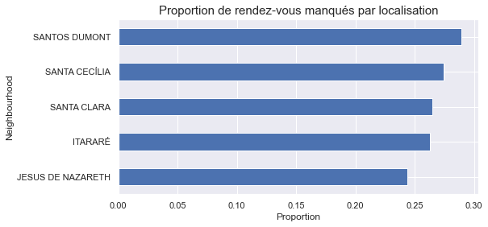

```python
plt.figure(figsize=(8, 4))
prop_rdv_manq_loc.sort_values(ascending=False).head(5).sort_values().plot(kind='barh')
plt.xlabel("Proportion")
plt.title("Proportion de rendez-vous manqués par localisation", fontsize=15);
```

Les 5 localisations avec le plus grand pourcentage de rendez-vous manqués sont:

1. **SANTOS DUMONT:** 28.9%
2. **SANTA CECÍLIA :** 27.5%
3. **SANTA CLARA:** 26.5%
4. **ITARARÉ:** 26.3%
5. **JESUS DE NAZARETH:** 24.4%

### Question 4 : Y a-t-il des jours de la semaine où les rendez-vous sont le plus manqués ?

> Voici comment nous procèderons. Nous allons d'abord utiliser le jour de la semaine pour grouper nos données. Nous calculerons le nombre total de rendez-vous pour chaque jour de la semaine. Ensuite, nous calculerons le nombre total de rendez-vous manqués pour chacun de ces jours. Nous serons ainsi en mesure de déterminer la proportion de rendez-vous manqués pour chaque jour de la semaine.  
> Pour éviter la repetition, nous allons créer la fonction *calc_prop* qui génèrera ces proportions pour nous.

```python
def calc_prop_miss(col):
    # Fonction permettant de déterminer la proportion de rendez-vous manqués d'une colonne de données

    # On détermine le nombre total de rendez-vous pour un groupe donné
    total_grp = df.groupby(col).count()['AppointmentID']
    # On détermine le nombre de rendez-vous manqués pour ce meme groupe
    miss_grp = df.query('No_show == 1').groupby(col).count()['AppointmentID']
    # On génère la proportion de rendez-vous manqués
    return miss_grp / total_grp
```

**Caculons la proportion de rendez-vous manqués pour chaque jour de la semaine (jours inclus dans la base de données)**

```python
print("Proportion de rendez-vous manqués")
dow_no_show_prop = calc_prop_miss('Appointment_dow')
dow_noshow_prop_sorted = dow_no_show_prop.sort_values(ascending=False)
dow_noshow_prop_sorted
```

```
Proportion de rendez-vous manqués
```

```
Appointment_dow
Saturday     0.230769
Friday       0.212261
Monday       0.206471
Tuesday      0.200936
Wednesday    0.196892
Thursday     0.193541
Name: AppointmentID, dtype: float64
```

Utilisons un graphique poiur mieux visualiser le tableau ci-dessus.

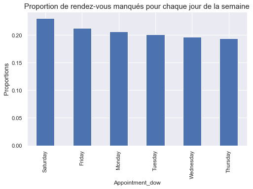

```python
plt.figure(figsize=(8, 5))
dow_noshow_prop_sorted.plot(kind="bar")
plt.ylabel("Proportions", fontsize = 13)
plt.title("Proportion de rendez-vous manqués pour chaque jour de la semaine", fontsize = 15);
```

La journée du **samedi** est celle avec le plus grand pourcentage de rendez-vous manqués (23%). Mais les autres jours ont des pourcentages qui ne sont pas vraiment éloignés. Comme par exemple vendredi(21%) et lundi(20%).

### Question 5 : Qu’en est-il des heures de rendez-vous ?

Nous allons reproduire l'opération précédente, en nous concentrant cette fois-ci sur les heures de rendez-vous.

```python
# Calculons la proportion de rendez-vous manqués pour chaque heure de rendez-vous
hr_noshow_prop = calc_prop_miss('Appointment_hour')
hr_noshow_prop_sorted =hr_noshow_prop.sort_values(ascending=False)
print("Proportion de rendez-vous manqués")
hr_noshow_prop_sorted
```

```
Proportion de rendez-vous manqués
```

```
Appointment_hour
21    0.333333
20    0.300000
17    0.248195
16    0.237640
19    0.233607
15    0.231836
11    0.227842
14    0.226800
10    0.220695
18    0.212687
13    0.209274
12    0.203615
9     0.196990
6     0.192015
8     0.182683
7     0.151512
Name: AppointmentID, dtype: float64
```

Visualisons cela via un graphique.

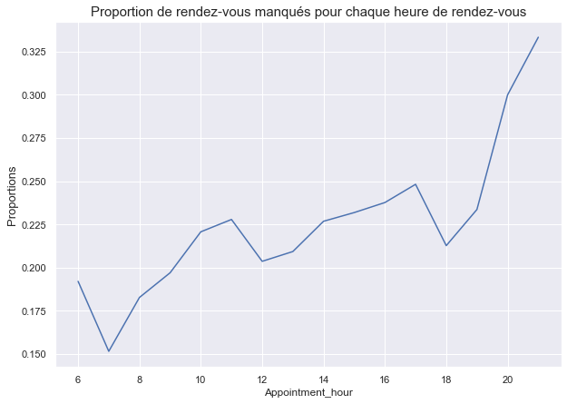

```python
plt.figure(figsize=(10, 7))
hr_noshow_prop.plot(kind="line")
plt.ylabel("Proportions", fontsize = 13)
plt.title("Proportion de rendez-vous manqués pour chaque heure de rendez-vous", fontsize = 15);
```

- On observe un pic en terme de pourcentage de rendez-vous manqués pour **20h et 21h** (30 et 33% respectivement)
- Les plus faibles pourcentages de rendez-vous manqués concernent les heures très matinales **(entre 6h et 9h)**

### Question 6 : Les patients qui ont reçu des messages viennent t-ils plus à leur rendez-vous?

Regroupons les patients en deux groupes:

- Groupe 1: Ceux qui ont reçu un ou plusieurs messages
- Groupe 2: Ce qui n'ont pas reçu de messages

```python
# Apres regroupement, observons comment varient les proportions de chaque attribut
df.groupby('SMS_received').mean()
```

| SMS_received | Age | Scholarship | Hipertension | Diabetes | Alcoholism | Handcap | No_show | Appointment_hour |
| --- | --- | --- | --- | --- | --- | --- | --- | --- |
| 0 | 36.887961 | 0.098021 | 0.198961 | 0.074449 | 0.033487 | 0.024932 | 0.167033 | 10.641135 |
| 1 | 37.513810 | 0.098782 | 0.193619 | 0.066400 | 0.023871 | 0.016572 | 0.275745 | 11.056620 |

### Patients avec messages

- **28%** des patients **qui ont reçu des messages** **ne sont pas venus** au rendez-vous. En d'autres termes, **72%** des patients **qui ont reçu des messages** **sont venus** au rendez-vous.  
  Un grand pourcentage de patients qui ont reçu des messages sont venus au rendez-vous. Pour avoir une meilleure idée de l'impact des messages, posons nous maitenant cette question:

Quel pourcentage des personnes n'ayant pas reçu de messages sont venus au rendez-vous?

### Patients sans messages

D'après le tableau précedent:

- **17%** des patients qui n'ont pas reçu de messages **ne sont pas venus** au rendez-vous. En d'autres termes, **83%** des patients qui n'ont pas reçu de messages **sont venus** au rendez-vous.

Ainsi:

- **72%** des patients qui ont reçu des messages **sont venus** au rendez-vous.
- **83%** des patients qui n'ont pas reçu de messages **sont venus** au rendez-vous.

Il **se pourrait** que les messages aient un impact sur le fait de se présenter ou pas au rendez-vous. En effet, ceux qui viennent au rendez-vous **sans messages** représentent un plus grand pourcentage que ce qui viennent au rendez-vous **avec** messages (83% contre 72%). Il s'agit d'une observation, qui nécessitera des investigations futures.

## IV - Conclusions

Après l'exploration et la visualisation des données précédentes, les observations suivantes ont été faites.

**Par rapport à l'âge des patients:**

Les groupes de patients de 10-20 ans et 20-30 ans sont ceux avec les plus grandes proportions de rendez-vous manqués avec:

- **10-20 ans**: 25.3% de rendez-vous manqués
- **20-30 ans**: 24.6% de rendez-vous manqués

**En ce qui concerne les localisations des hopitaux:**

Les 5 localisations avec le plus grand pourcentage de rendez-vous manqués sont:

1. **SANTOS DUMONT:** 28.9% de rdv manqués
2. **SANTA CECÍLIA :** 27.5%
3. **SANTA CLARA:** 26.5%
4. **ITARARÉ:** 26.3%
5. **JESUS DE NAZARETH:** 24.4%

**Par rapport aux jours de la semaine:**

La journée du **samedi** est celle avec le plus grand pourcentage de rendez-vous manqués (23%). Mais les autres jours ont des pourcentages qui ne sont pas vraiment éloignés. Comme par exemple vendredi (21%) et lundi (20%).

**Par rapport aux heures de la semaine:**

- On observe un pic en terme de pourcentage de rendez-vous manqués pour ceux de **20h et 21h** (30 et 33% respectivement)
- Les plus faibles pourcentages de rendez-vous manqués concernent les heures très matinales **(entre 6h et 9h)**

**Concernant les messages reçus par les patients:**

Il **se pourrait** que les messages aient un impact sur le fait de se présenter ou pas au rendez-vous. En effet, ceux qui viennent au rendez-vous **sans messages** représentent un plus grand pourcentage que ce qui viennent au rendez-vous **avec** messages (83% contre 72%). Il s'agit d'une observation, qui nécessitera des investigations futures.

Pour tirer des conclusions, il sera question d'effectuer des tests statistiques. Ceci fera certainement l'objet d'un prochain rapport.

Ressources utilisées:

- [seaborn pydata](http://seaborn.pydata.org/tutorial/aesthetics.html)
- [matplotlib bar chart](https://pythonguides.com/matplotlib-bar-chart-labels/)
- [unicode characters](https://en.wikipedia.org/wiki/List_of_Unicode_characters)
- [resize images in jupyter notebooks](https://stackoverflow.com/questions/41598916/resize-the-image-in-jupyter-notebook-using-markdown)
- [convert columns to strings](https://stackoverflow.com/questions/22005911/convert-columns-to-string-in-pandas)